# ERBB2 mRNA and RPPA protein expression in TCGA-BRCA

Author: Ondine Grosser

Last update: 09 June, 2025

# 1 Important Note

Make sure the following libraries downloaded to your workspace before running any of the below code.

```r
library("data.table")
library("DT")
library("dplyr")
```

Before answering the questions below I read the clinical data, mRNA expression data, and RPPA protein expression data into my workspace.

```r
#Clinical data
clin.data <- read.csv('TCGA_BRCA_clinical_data.csv', sep=',', header = T)
datatable(head(as.data.frame(clin.data),10), filter = 'top', options = list(pageLength = 10, scrollX = TRUE, scrollY = "400px", autoWidth = TRUE))
```

|  | Patient_ID | Sample_ID_Tumor | Sample_ID_Normal | Diagnosis_Age | Disease_Stage | Tumor_Stge_Coe | Cancer_Type_Detailed | Disease_Free_Months | Disease_Free_Status | ER_Status_By_IHC | Fraction_Genome_Altered | IHCHER2 | Overall_Survival_Months | Overall_Survival_Status | PR_status_by_ihc | Race_Category | Sex | TMB_nonsynonymous |
| --- | --- | --- | --- | --- | --- | --- | --- | --- | --- | --- | --- | --- | --- | --- | --- | --- | --- | --- |
| 1 | TCGA_A7_A0CE | TCGA_A7_A0CE_01 | TCGA_A7_A0CE_11 | 57 | Stage II | T2 | Breast Invasive Ductal Carcinoma | 35.28 | 0:DiseaseFree | Negative | 0.4998 | Equivocal | 35.28 | 0:LIVING | Negative | WHITE | Female | 5.3 |
| 2 | TCGA_A7_A0CH | TCGA_A7_A0CH_01 | TCGA_A7_A0CH_11 | 79 | Stage II | T2 | Breast Invasive Ductal Carcinoma | 35.45 | 0:DiseaseFree |  | 0.0627 |  | 35.45 | 0:LIVING |  | WHITE | Female | 1.4 |
| 3 | TCGA_A7_A0D9 | TCGA_A7_A0D9_01 | TCGA_A7_A0D9_11 | 37 | Stage II | T2 | Breast Invasive Ductal Carcinoma | 37.42 | 0:DiseaseFree | Positive | 0.1867 | Negative | 37.42 | 0:LIVING | Negative | WHITE | Female | 1.3 |
| 4 | TCGA_A7_A0DB | TCGA_A7_A0DB_01 | TCGA_A7_A0DB_11 | 56 | Stage II | T2 | Breast Invasive Ductal Carcinoma | 33.08 | 0:DiseaseFree | Positive | 0.3296 | Negative | 33.08 | 0:LIVING | Positive | WHITE | Female | 3.166666667 |
| 5 | TCGA_A7_A13E | TCGA_A7_A13E_01 | TCGA_A7_A13E_11 | 62 | Stage II | T2 | Breast Invasive Ductal Carcinoma | 18.27 | 1:Recurred/Progressed | Positive | 0.6513 | Equivocal | 20.17 | 1:DECEASED | Negative | WHITE | Female | 6.9 |
| 6 | TCGA_A7_A13F | TCGA_A7_A13F_01 | TCGA_A7_A13F_11 | 44 | Stage III | T3 | Breast Invasive Ductal Carcinoma | 25.13 | 0:DiseaseFree | Positive | 0.2607 | Equivocal | 25.13 | 0:LIVING | Positive | WHITE | Female | 1.866666667 |
| 7 | TCGA_AC_A2FB | TCGA_AC_A2FB_01 | TCGA_AC_A2FB_11 | 65 | Stage II | T2 | Breast Invasive Lobular Carcinoma | 40.54 | 0:DiseaseFree | Positive | 0.0024 | Positive | 40.54 | 0:LIVING | Positive | WHITE | Female | 0.433333333 |
| 8 | TCGA_AC_A2FF | TCGA_AC_A2FF_01 | TCGA_AC_A2FF_11 | 40 | Stage II | T2 | Breast Invasive Lobular Carcinoma | 90.64 | 0:DiseaseFree | Positive | 0.0011 |  | 90.64 | 0:LIVING | Positive | ASIAN | Female | 0.5 |
| 9 | TCGA_AC_A2FM | TCGA_AC_A2FM_01 | TCGA_AC_A2FM_11 | 87 | Stage II | T2 | Breast Invasive Lobular Carcinoma | 25.62 | 1:Recurred/Progressed |  | 0.4843 |  | 26.02 | 1:DECEASED |  | WHITE | Female | 1.2 |
| 10 | TCGA_BH_A0AU | TCGA_BH_A0AU_01 | TCGA_BH_A0AU_11 | 45 | Stage II | T2 | Breast Invasive Ductal Carcinoma | 62.88 | 0:DiseaseFree | Positive | 0.4255 | Positive | 62.88 | 0:LIVING | Positive | WHITE | Female | 0.466666667 |

```r
#mRNA expression data
mRNA.data <- read.csv('TCGA_BRCA_mRNA_expression.csv', sep=',', header = T)
datatable(head(as.data.frame(mRNA.data),10), filter = 'top', options = list(pageLength = 10, scrollX = TRUE, scrollY = "400px", autoWidth = TRUE))
```

|  | X | TCGA_A7_A0CE_01 | TCGA_A7_A0CH_01 | TCGA_A7_A0D9_01 | TCGA_A7_A0DB_01 | TCGA_A7_A13E_01 | TCGA_A7_A13F_01 | TCGA_AC_A2FB_01 | TCGA_AC_A2FF_01 | TCGA_AC_A2FM_01 | TCGA_BH_A0AU_01 | TCGA_BH_A0AY_01 | TCGA_BH_A0AZ_01 | TCGA_BH_A0B3_01 | TCGA_BH_A0B5_01 | TCGA_BH_A0B7_01 | TCGA_BH_A0BA_01 | TCGA_BH_A0BC_01 | TCGA_BH_A0BJ_01 | TCGA_BH_A0BM_01 | TCGA_BH_A0BQ_01 | TCGA_BH_A0BS_01 | TCGA_BH_A0BT_01 | TCGA_BH_A0BV_01 | TCGA_BH_A0BW_01 | TCGA_BH_A0BZ_01 | TCGA_BH_A0C0_01 | TCGA_BH_A0C3_01 | TCGA_BH_A0DD_01 | … |
| --- | --- | --- | --- | --- | --- | --- | --- | --- | --- | --- | --- | --- | --- | --- | --- | --- | --- | --- | --- | --- | --- | --- | --- | --- | --- | --- | --- | --- | --- | --- |
| 1 | A1BG | 127.05 | 217.27 | 181 | 790.57 | 270.08 | 575.21 | 309.71 | 268.98 | 3889.49 | 325.48 | 355.97 | 334.93 | 501.29 | 334.16 | 354.42 | 363.33 | 597.94 | 591.95 | 388.75 | 227.8 | 340.04 | 321.11 | 585.46 | 49 | 136.22 | 592.66 | 308.68 | 329.85 | … |
| 2 | A1CF | 1 | 0 | 0 | 2 | 1 | 0 | 0 | 0 | 1 | 0 | 0 | 0 | 0 | 0 | 0 | 1 | 0 | 0 | 0 | 0 | 0 | 0 | 0 | 0 | 0 | 0 | 0 | 0 | … |
| 3 | A2BP1 | 0 | 1 | 0 | 6 | 0 | 0 | 4 | 2 | 0 | 0 | 0 | 1 | 1 | 1 | 0 | 0 | 0 | 1 | 2 | 1 | 1 | 0 | 0 | 0 | 1 | 4 | 0 | 6 | … |
| 4 | A2LD1 | 408.58 | 219.44 | 234.75 | 283.82 | 233.65 | 112.67 | 331.81 | 315.23 | 324.94 | 108.71 | 186.78 | 310.49 | 259.86 | 235.4 | 119.78 | 197.71 | 245.48 | 336.06 | 139.04 | 241.11 | 317.45 | 361.74 | 158.56 | 348.06 | 167.76 | 72.72 | 191.35 | 207.11 | … |
| 5 | A2ML1 | 37 | 6 | 61 | 5 | 9891 | 0 | 1 | 28 | 0 | 0 | 86 | 5 | 1448 | 24 | 11 | 40 | 7 | 1 | 18 | 14 | 17 | 4 | 0 | 1798 | 37 | 121 | 5 | 0 | … |
| 6 | A2M | 27927.63 | 12274.92 | 27716.96 | 32169.68 | 11586.74 | 32853.93 | 79163.71 | 113580.41 | 22171.86 | 19979 | 50528.81 | 60361.84 | 27934.96 | 32272.89 | 61873.78 | 41319.76 | 77810.87 | 49178.79 | 17811.38 | 43568.85 | 23319.91 | 19386.95 | 37429.96 | 168564.89 | 63937.79 | 23960.92 | 57889.84 | 11458.99 | … |
| 7 | A4GALT | 339 | 273 | 666 | 423 | 248 | 243 | 540 | 911 | 2478 | 1519 | 1052 | 1363 | 1351 | 526 | 841 | 487 | 992 | 507 | 387 | 847 | 621 | 630 | 2049 | 702 | 969 | 1072 | 954 | 1432 | … |
| 8 | A4GNT | 10 | 1 | 11 | 1 | 2 | 0 | 5 | 0 | 3 | 4 | 0 | 3 | 1 | 2 | 1 | 2 | 3 | 0 | 5 | 0 | 1 | 1 | 3 | 14 | 2 | 0 | 8 | 0 | … |
| 9 | AAA1 | 0 | 0 | 0 | 0 | 0 | 0 | 0 | 0 | 0 | 0 | 0 | 0 | 1 | 0 | 0 | 0 | 1 | 1 | 0 | 0 | 0 | 0 | 0 | 0 | 0 | 0 | 0 | 0 | … |
| 10 | AAAS | 2058 | 1590 | 1626 | 1964 | 1689 | 2273 | 1708 | 2000 | 2793 | 1472 | 1127 | 1536 | 1306 | 2884 | 1413 | 2035 | 2910 | 1952 | 958 | 1418 | 1938 | 2812 | 1803 | 676 | 2531 | 1003 | 1378 | 1778 | … |

```r
#RPPA expression data
RPPA.data <- read.csv('TCGA_BRCA_RPPA_protein_expression.csv', sep=',', header = T)
datatable(head(as.data.frame(RPPA.data),10), filter = 'top', options = list(pageLength = 10, scrollX = TRUE, scrollY = "400px", autoWidth = TRUE))
```

|  | X | TCGA_AC_A2FM_01 | TCGA_AC_A2FF_01 | TCGA_AC_A2FB_01 | TCGA_GI_A2C9_01 | TCGA_BH_A1FE_01 | TCGA_BH_A18V_01 | TCGA_E2_A15K_01 | TCGA_BH_A0B3_01 | TCGA_BH_A0AZ_01 | TCGA_BH_A0BJ_01 | TCGA_BH_A0BS_01 | TCGA_BH_A0BW_01 | TCGA_BH_A0B7_01 | TCGA_BH_A0H7_01 | TCGA_A7_A13E_01 | TCGA_A7_A13F_01 | TCGA_E2_A15K.1_01 | TCGA_BH_A18V.1_01 | TCGA_BH_A18P_01 | TCGA_BH_A18L_01 | TCGA_BH_A1FR_01 | TCGA_BH_A1EN_01 | TCGA_BH_A1F8_01 | TCGA_BH_A1FG_01 | TCGA_BH_A1FH_01 | TCGA_BH_A1FJ_01 | TCGA_BH_A1EV_01 | TCGA_E9_A1N4_01 | … |
| --- | --- | --- | --- | --- | --- | --- | --- | --- | --- | --- | --- | --- | --- | --- | --- | --- | --- | --- | --- | --- | --- | --- | --- | --- | --- | --- | --- | --- | --- | --- |
| 1 | YWHAE | 0.089599 | 0.10613 | 0.30803 | 0.19347 | 0.0018226 | 0.10736 | 0.13803 | -0.029081 | 0.35911 | 0.2051 | 0.12633 | -0.053108 | 0.073201 | 0.46922 | -0.13256 | 0.0065351 | -0.062485 | 0.026616 | -0.071207 | 0.016827 | 0.060546 | 0.08196 | -0.095374 | -0.037828 | 0.25073 | -0.098785 | -0.16866 | -0.0048666 | … |
| 2 | EIF4EBP1 | 0.013462 | -0.47997 | -0.96245 | 0.27109 | -0.59869 | 0.01799 | -0.28973 | -0.28403 | -0.25509 | 0.14763 | 0.20333 | -0.3517 | -0.49047 | -0.6118 | 0.69571 | 0.53977 | -0.39744 | 0.4179 | -0.38751 | -0.45405 | 0.29923 | 1.7396 | 0.52099 | 1.1259 | -0.06384 | 0.16789 | 0.16772 | 0.26166 | … |
| 3 | TP53BP1 | -0.20413 | -0.40649 | -1.0447 | -0.82114 | -0.2129 | 0.11047 | 0.46487 | -0.72963 | -0.52391 | 0.58538 | 0.20481 | -0.51025 | 0.18934 | -1.1814 | 0.033255 | 0.22476 | 0.19025 | 0.37017 | 0.79955 | -0.70678 | 0.6105 | -0.84475 | -0.43622 | -0.82001 | -0.71789 | 0.80116 | 0.0035638 | 0.17831 | … |
| 4 | ACACA ACACB | 1.209 | -0.25755 | -0.78527 | -0.026602 | 0.35911 | -0.77505 | 0.30832 | -0.12976 | -0.86203 | 0.058751 | 0.04931 | 0.91022 | 0.28377 | -0.35012 | -0.11288 | 0.35466 | -0.13419 | 0.020699 | 0.15538 | 1.1032 | 0.76393 | 1.1187 | 1.2223 | 0.8497 | -0.47813 | 1.0367 | 0.048622 | 0.59925 | … |
| 5 | ACACA | 1.4541 | -0.45275 | -1.4109 | -0.050567 | -0.058453 | -1.1837 | 0.17 | -0.084518 | 0.2322 | 0.45428 | 1.017 | 0.84621 | 1.4618 | -0.91348 | -0.41671 | 1.154 | -0.57089 | -0.24254 | -0.33214 | 1.0097 | 0.5099 | 0.99547 | 1.1883 | 1.0379 | -0.88798 | 0.96451 | -0.38324 | 0.90754 | … |
| 6 | AKT1 AKT2 AKT3 | 0.67869 | -0.066244 | -0.66492 | 0.39365 | 0.055186 | -0.18461 | 0.31675 | -0.1887 | 0.24829 | 0.24893 | 0.5556 | 1.1594 | 0.33165 | -0.78542 | -0.51953 | -0.031287 | 0.46116 | -0.026857 | 0.41926 | -0.073446 | 0.57585 | 0.55242 | 0.013652 | -0.091305 | 0.17702 | 0.44582 | 0.47495 | 0.21987 | … |
| 7 | PRKAA1 | -0.06286 | -0.10458 | -0.53425 | -0.21811 | 0.027937 | -0.23346 | 0.13893 | -0.26315 | -0.10707 | 0.30266 | -0.22088 | -0.29955 | 0.11874 | -0.81706 | -0.5935 | -0.92432 | 0.055721 | -0.21194 | 0.85433 | -0.66219 | 0.012278 | 0.35051 | -0.51841 | -0.3481 | -0.26672 | 0.65006 | 0.18394 | 0.56377 | … |
| 8 | AR | 2.0842 | 1.3745 | 0.74599 | -0.21623 | 0.49996 | 0.10797 | 2.583 | -0.29327 | 0.63627 | 1.6561 | 1.533 | -0.50712 | 0.99802 | 0.71928 | -0.94561 | 1.4721 | 1.2962 | -0.87593 | 1.0004 | 0.62797 | 1.6998 | 0.82028 | 1.6079 | 1.6929 | 0.444 | 2.1883 | 0.12914 | 1.1776 | … |
| 9 | ASNS | 0.41665 | -0.24251 | -0.25281 | 1.0881 | 0.020348 | 1.1371 | -1.2504 | 0.86782 | -0.69608 | -0.057143 | -0.56652 | 0.52102 | -0.58533 | -0.67505 | 0.74728 | 0.14017 | -0.85712 | 1.2981 | 0.13484 | -0.27937 | -0.13778 | -0.40484 | 0.38033 | -0.8002 | -0.25069 | 0.3886 | -0.37067 | -0.57438 | … |
| 10 | ATM | -0.80731 | 0.18909 | -0.20788 | 0.15434 | 0.28684 | -0.39309 | 0.15483 | -0.24193 | -0.15711 | 0.92518 | 0.47157 | 0.78051 | 0.48711 | -0.83434 | -0.67601 | 0.63736 | -0.2373 | -0.68646 | -0.61788 | -0.47574 | 1.0312 | -0.65332 | 0.12182 | 0.79497 | -0.37401 | 0.94901 | 0.13191 | 0.36653 | … |

**Side Note:** Both mRNA.data and RPPA.data are not normally distributed, so I will use a Mann-Whitney U test instead of a t-test. The Shapiro-Wilk test for mRNA.data only covers the first 5000 rows because that is the limit of the function sample size.

```r
#Shapiro-Wilk test for mRNA expression data distribution
normal <- 0
not.normal <- 0
for (i in 2:207) { #for all columns in data set except X column
    #if p-value is greater than 0.05, column is normally distributed
    if (shapiro.test(as.numeric(mRNA.data[1:5000, i]))$p > 0.05) {
        normal <- normal + 1
    }else {
        not.normal <- not.normal + 1
    }
}
normal; not.normal
```

```
## [1] 0
```

```
## [1] 206
```

```r
#Shapiro-Wilk test for RPPA protein expression data distribution
normal <- 0
not.normal <- 0
for (i in 2:107) { #for all columns in data set except outcome column
    #if p-value is greater than 0.05, column is normally distributed
    if (shapiro.test(as.numeric(RPPA.data[[i]]))$p > 0.05) {
        normal <- normal + 1
    }else {
        not.normal <- not.normal + 1
    }
}
normal; not.normal
```

```
## [1] 0
```

```
## [1] 106
```

# 2 Question 1

**Investigate whether the ERBB2 (HER2) mRNA expression is significantly different between normal and tumor tissues. Perform both an unpaired t-test and a paired t-test. Clearly explain the results from each test and discuss which test is more appropriate for answering this question. Ensure that you state the null hypothesis clearly and indicate whether you accept or reject it based on the results obtained.**

I made a variable containing the expression data from the ‘ERBB2’ row from mRNA.data. Then I made a dataframe with the values from the normal/tumor tissues in different columns. The normal tissues have an ID ending in “11” and the tumor tissues have an ID ending in “01”.

```r
#ERBB2 mRNA expression in all tissue samples
ERBB2 <- mRNA.data[mRNA.data$X=='ERBB2', ]
#First 30 columns
datatable(as.data.frame(ERBB2[, 1:30]), filter = 'top', options = list(pageLength = 10, scrollX = TRUE, autoWidth = TRUE))
```

|  | X | TCGA_A7_A0CE_01 | TCGA_A7_A0CH_01 | TCGA_A7_A0D9_01 | TCGA_A7_A0DB_01 | TCGA_A7_A13E_01 | TCGA_A7_A13F_01 | TCGA_AC_A2FB_01 | TCGA_AC_A2FF_01 | TCGA_AC_A2FM_01 | TCGA_BH_A0AU_01 | TCGA_BH_A0AY_01 | TCGA_BH_A0AZ_01 | TCGA_BH_A0B3_01 | TCGA_BH_A0B5_01 | TCGA_BH_A0B7_01 | TCGA_BH_A0BA_01 | TCGA_BH_A0BC_01 | TCGA_BH_A0BJ_01 | TCGA_BH_A0BM_01 | TCGA_BH_A0BQ_01 | TCGA_BH_A0BS_01 | TCGA_BH_A0BT_01 | TCGA_BH_A0BV_01 | TCGA_BH_A0BW_01 | TCGA_BH_A0BZ_01 | TCGA_BH_A0C0_01 | TCGA_BH_A0C3_01 | TCGA_BH_A0DD_01 | … |
| --- | --- | --- | --- | --- | --- | --- | --- | --- | --- | --- | --- | --- | --- | --- | --- | --- | --- | --- | --- | --- | --- | --- | --- | --- | --- | --- | --- | --- | --- | --- |
| 5650 | ERBB2 | 22171 | 17513 | 12853 | 21937 | 19930 | 28183 | 226629 | 32228 | 66669 | 22756 | 8329 | 12429 | 11391 | 23814 | 587741 | 22736 | 9142 | 22836 | 10467 | 24503 | 34001 | 40795 | 15941 | 16735 | 22262 | 21878 | 14813 | 104210 | … |

```r
#ERBB2 expression in normal tissues
ERBB2.n <- as.numeric(ERBB2[, grep("11", names(ERBB2), value = TRUE)])
#ERBB2 expression in tumor tissues
ERBB2.t <- as.numeric(ERBB2[, grep("01", names(ERBB2), value = TRUE)])
ERBB2.split <- data.frame(Tumor=ERBB2.t, Normal=ERBB2.n)
datatable(head(as.data.frame(ERBB2.split),10), filter = 'top', options = list(pageLength = 10, scrollX = TRUE, scrollY = "400px", autoWidth = TRUE))
```

|  | Tumor | Normal |
| --- | --- | --- |
| 1 | 22171 | 21269 |
| 2 | 17513 | 13269 |
| 3 | 12853 | 2109 |
| 4 | 21937 | 1359 |
| 5 | 19930 | 5599 |
| 6 | 28183 | 6477 |
| 7 | 226629 | 13795 |
| 8 | 32228 | 24155 |
| 9 | 66669 | 19458 |
| 10 | 22756 | 14159 |

The null hypothesis for the Mann Whitney U test is that there is no significant difference in ERBB2 expression between normal and tumor tissues. The unpaired Mann Whiteney U test gives a p-value of 7.562e-07 and the paired Mann Whitney U test gives a p-value of 7.558e-08. Both Mann Whitney U tests give p-values less than 0.05 and reject the null hypothesis. The best t-test to use in this case is the unpaired Mann Whitney U test because the two mRNA expression groups (normal and tumor) are independent of each other.

```r
#Unpaired Mann Whitney U test
wilcox.test(ERBB2.split$Normal, ERBB2.split$Tumor)
```

```
##
##  Wilcoxon rank sum test with continuity correction
##
## data:  ERBB2.split$Normal and ERBB2.split$Tumor
## W = 3188, p-value = 7.562e-07
## alternative hypothesis: true location shift is not equal to 0
```

```r
#Paired Mann Whitney U test
wilcox.test(ERBB2.split$Normal, ERBB2.split$Tumor, paired = TRUE)
```

```
##
##  Wilcoxon signed rank test with continuity correction
##
## data:  ERBB2.split$Normal and ERBB2.split$Tumor
## V = 1043, p-value = 7.558e-08
## alternative hypothesis: true location shift is not equal to 0
```

# 3 Question 2

**Analyze the correlation between ERBB2 (HER2) mRNA expression and RPPA protein levels in HER2-IHC negative patients. Calculate both the Pearson and Spearman correlation coefficients, along with their respective p-values, for ERBB2 mRNA and RPPA protein levels. Clearly explain the results from each correlation method and discuss which method is more appropriate for this analysis. Ensure you state the null hypothesis clearly and indicate whether you accept or reject it based on the results obtained.**

First I found which patients were HER2-IHC negative, not counting the ones with NA values.

```r
#Only HER2-IHC negative patients
clin.data.2 <- clin.data[clin.data$IHCHER2=='Negative', ]
#Excluding NA values
clin.data.2 <- na.exclude(clin.data.2)
clin.data.2$Patient_ID
```

```
##  [1] "TCGA_A7_A0D9" "TCGA_A7_A0DB" "TCGA_BH_A0AY" "TCGA_BH_A0AZ" "TCGA_BH_A0B3"
##  [6] "TCGA_BH_A0B5" "TCGA_BH_A0BA" "TCGA_BH_A0BC" "TCGA_BH_A0BJ" "TCGA_BH_A0BM"
## [11] "TCGA_BH_A0BT" "TCGA_BH_A0BV" "TCGA_BH_A0BZ" "TCGA_BH_A0C3" "TCGA_BH_A0DG"
## [16] "TCGA_BH_A0DH" "TCGA_BH_A0DK" "TCGA_BH_A0DL" "TCGA_BH_A0DP" "TCGA_BH_A0DT"
## [21] "TCGA_BH_A0DV" "TCGA_BH_A0E0" "TCGA_BH_A0H7" "TCGA_BH_A0HK" "TCGA_E2_A153"
## [26] "TCGA_E2_A158" "TCGA_E2_A1IG" "TCGA_E2_A1L7" "TCGA_E9_A1NF" "TCGA_GI_A2C8"
## [31] "TCGA_GI_A2C9"
```

Then I made a variable containing the RPPA protein expression data for ERBB2.

```r
#ERBB2 RPPA protein expression in all tissue samples
ERBB2.R <- RPPA.data[RPPA.data$X=="ERBB2", ]
datatable(as.data.frame(ERBB2.R[, 1:30]), filter = 'top', options = list(pageLength = 10, scrollX = TRUE, autoWidth = TRUE))
```

|  | X | TCGA_AC_A2FM_01 | TCGA_AC_A2FF_01 | TCGA_AC_A2FB_01 | TCGA_GI_A2C9_01 | TCGA_BH_A1FE_01 | TCGA_BH_A18V_01 | TCGA_E2_A15K_01 | TCGA_BH_A0B3_01 | TCGA_BH_A0AZ_01 | TCGA_BH_A0BJ_01 | TCGA_BH_A0BS_01 | TCGA_BH_A0BW_01 | TCGA_BH_A0B7_01 | TCGA_BH_A0H7_01 | TCGA_A7_A13E_01 | TCGA_A7_A13F_01 | TCGA_E2_A15K.1_01 | TCGA_BH_A18V.1_01 | TCGA_BH_A18P_01 | TCGA_BH_A18L_01 | TCGA_BH_A1FR_01 | TCGA_BH_A1EN_01 | TCGA_BH_A1F8_01 | TCGA_BH_A1FG_01 | TCGA_BH_A1FH_01 | TCGA_BH_A1FJ_01 | TCGA_BH_A1EV_01 | TCGA_E9_A1N4_01 | … |
| --- | --- | --- | --- | --- | --- | --- | --- | --- | --- | --- | --- | --- | --- | --- | --- | --- | --- | --- | --- | --- | --- | --- | --- | --- | --- | --- | --- | --- | --- | --- |
| 51 | ERBB2 | 1.1091 | 0.33036 | 0.076741 | -0.4345 | -0.69598 | -0.082359 | 0.79928 | -0.45593 | -0.33701 | 0.020262 | 1.5421 | -0.26271 | 3.3806 | -0.71732 | 0.50057 | 1.1018 | 0.77153 | 0.22487 | 0.70033 | 0.42108 | -0.2201 | 3.5792 | 0.55488 | 0.35115 | -0.52087 | 0.9517 | 2.9157 | 0.41204 | … |

Then I made vectors of the values from ERBB2 and ERBB2.R that matched clin.data.2$Patient_ID. Since the RPPA data set only contains tumor tissue samples, both vectors will only contain expression levels from tumor tissue samples.

```r
ERBB2.HER2 <- character(0) #mRNA expression of HER2 neg. patients
ERBB2.R.HER2 <- character(0) #protein expression of HER2 neg. patients
for (i in clin.data.2$Patient_ID) {
    ERBB2.HER2 <- append(ERBB2.HER2, as.numeric(ERBB2[grep(i, colnames(ERBB2))[1]]))
    ERBB2.R.HER2 <- append(ERBB2.R.HER2, as.numeric(ERBB2.R[grep(i, colnames(ERBB2.R))]))
}
```

After making a dataframe containing the above vectors, I calculated both the Pearson and Spearman correlation coefficients and kept the p-values. The null hypothesis is that there is no signficant correlation between the ERBB2 mRNA expression and ERBB2 RPPA protein expression in HER2-IHC negative patients. Both correlation coefficients are positive, which means that both tests show a positive correlation. Both p-values are below 0.05, which means that the null hypothesis should be rejected. Therefore, according to both tests there is a significant positive correlation between the mRNA expression and RPPA protein expression. Since the all of the data is not normally distributed, the Spearman test would be better. This is because the Spearman test is nonparametric while the Pearson test is parametric.

```r
HER2 <- data.frame(E.mRNA=ERBB2.HER2, E.RPPA=ERBB2.R.HER2)
datatable(head(as.data.frame(HER2),10), filter = 'top', options = list(pageLength = 10, scrollX = TRUE, scrollY = "400px", autoWidth = TRUE))
```

|  | E.mRNA | E.RPPA |
| --- | --- | --- |
| 1 | 12853 | 0.34235 |
| 2 | 21937 | 0.30563 |
| 3 | 8329 | -1.1011 |
| 4 | 12429 | -0.33701 |
| 5 | 11391 | -0.45593 |
| 6 | 23814 | -0.53364 |
| 7 | 22736 | -0.038669 |
| 8 | 9142 | -0.56253 |
| 9 | 22836 | 0.020262 |
| 10 | 10467 | 0.37459 |

```r
#Pearson correlation test
cor.test(as.numeric(HER2$E.mRNA), as.numeric(HER2$E.RPPA), method = "pearson")
```

```
##
##  Pearson's product-moment correlation
##
## data:  as.numeric(HER2$E.mRNA) and as.numeric(HER2$E.RPPA)
## t = 2.1511, df = 29, p-value = 0.03993
## alternative hypothesis: true correlation is not equal to 0
## 95 percent confidence interval:
##  0.01913029 0.64103536
## sample estimates:
##       cor
## 0.3709558
```

```r
#Spearman correlation test
cor.test(as.numeric(HER2$E.mRNA), as.numeric(HER2$E.RPPA), method = "spearman")
```

```
##
##  Spearman's rank correlation rho
##
## data:  as.numeric(HER2$E.mRNA) and as.numeric(HER2$E.RPPA)
## S = 3172, p-value = 0.04706
## alternative hypothesis: true rho is not equal to 0
## sample estimates:
##       rho
## 0.3604839
```

# 4 Question 3

**In breast cancer diagnostics, HER2 and ER statuses are critical biomarkers that influence treatment decisions. Oncologists are interested in the relationship between HER2-IHC and ER-IHC statuses in breast cancer patients. Please perform a test to determine if there is a significant association between HER2 and ER statuses in these patients. Ensure you state the null hypothesis clearly and indicate whether you accept or reject the null hypothesis based on the results obtained. (Only consider IHC positive and negative records, and remove NA, equivocal, and indeterminate records).**

First I made a fixed.status data frame that contains the tissue samples where both ER and HER2 are either positive or negative. Then I made a table with ER_Status_By_IHC and IHCHER2 column data and performed a chi-square test. The null hypothesis is that there is no significant association between HER2 and ER statuses among patients. The p-value is 1, which means that the null hypothesis should not be rejected and that there is no signficant association between HER2 and ER statuses.

```r
status <- c("Positive", "Negative")
#Only positive and negative ER patients
clin.data.ER <- filter(clin.data, grepl(paste(status, collapse='|'), ER_Status_By_IHC))
#Only patients where both ER and HER2 are positive/negative
fixed.status <- filter(clin.data.ER, grepl(paste(status, collapse='|'), IHCHER2))
datatable(head(as.data.frame(fixed.status),10), filter = 'top', options = list(pageLength = 10, scrollX = TRUE, scrollY = "400px", autoWidth = TRUE))
```

|  | Patient_ID | Sample_ID_Tumor | Sample_ID_Normal | Diagnosis_Age | Disease_Stage | Tumor_Stge_Coe | Cancer_Type_Detailed | Disease_Free_Months | Disease_Free_Status | ER_Status_By_IHC | Fraction_Genome_Altered | IHCHER2 | Overall_Survival_Months | Overall_Survival_Status | PR_status_by_ihc | Race_Category | Sex | TMB_nonsynonymous |
| --- | --- | --- | --- | --- | --- | --- | --- | --- | --- | --- | --- | --- | --- | --- | --- | --- | --- | --- |
| 1 | TCGA_A7_A0D9 | TCGA_A7_A0D9_01 | TCGA_A7_A0D9_11 | 37 | Stage II | T2 | Breast Invasive Ductal Carcinoma | 37.42 | 0:DiseaseFree | Positive | 0.1867 | Negative | 37.42 | 0:LIVING | Negative | WHITE | Female | 1.3 |
| 2 | TCGA_A7_A0DB | TCGA_A7_A0DB_01 | TCGA_A7_A0DB_11 | 56 | Stage II | T2 | Breast Invasive Ductal Carcinoma | 33.08 | 0:DiseaseFree | Positive | 0.3296 | Negative | 33.08 | 0:LIVING | Positive | WHITE | Female | 3.166666667 |
| 3 | TCGA_AC_A2FB | TCGA_AC_A2FB_01 | TCGA_AC_A2FB_11 | 65 | Stage II | T2 | Breast Invasive Lobular Carcinoma | 40.54 | 0:DiseaseFree | Positive | 0.0024 | Positive | 40.54 | 0:LIVING | Positive | WHITE | Female | 0.433333333 |
| 4 | TCGA_BH_A0AU | TCGA_BH_A0AU_01 | TCGA_BH_A0AU_11 | 45 | Stage II | T2 | Breast Invasive Ductal Carcinoma | 62.88 | 0:DiseaseFree | Positive | 0.4255 | Positive | 62.88 | 0:LIVING | Positive | WHITE | Female | 0.466666667 |
| 5 | TCGA_BH_A0AY | TCGA_BH_A0AY_01 | TCGA_BH_A0AY_11 | 62 | Stage II | T2 | Breast Invasive Ductal Carcinoma | 25.53 | 0:DiseaseFree | Positive | 0.2207 | Negative | 25.53 | 0:LIVING | Positive | WHITE | Female | 2.7 |
| 6 | TCGA_BH_A0AZ | TCGA_BH_A0AZ_01 | TCGA_BH_A0AZ_11 | 47 | Stage III | T3 | Breast Invasive Ductal Carcinoma | 63.04 | 0:DiseaseFree | Positive | 0.2853 | Negative | 63.04 | 0:LIVING | Positive | WHITE | Female | 1.533333333 |
| 7 | TCGA_BH_A0B3 | TCGA_BH_A0B3_01 | TCGA_BH_A0B3_11 | 53 | Stage II | T2 | Breast Invasive Ductal Carcinoma | 39.52 | 0:DiseaseFree | Negative | 0.2146 | Negative | 39.52 | 0:LIVING | Negative | WHITE | Female | 1.666666667 |
| 8 | TCGA_BH_A0B5 | TCGA_BH_A0B5_01 | TCGA_BH_A0B5_11 | 40 | Stage III | T2 | Breast Invasive Lobular Carcinoma | 70.17 | 0:DiseaseFree | Positive | 0.2328 | Negative | 70.17 | 0:LIVING | Positive | WHITE | Female | 1.7 |
| 9 | TCGA_BH_A0B7 | TCGA_BH_A0B7_01 | TCGA_BH_A0B7_11 | 42 | Stage II | T2 | Breast Invasive Ductal Carcinoma | 84.07 | 0:DiseaseFree | Positive | 0.1253 | Positive | 84.07 | 0:LIVING | Positive | WHITE | Female | 0.633333333 |
| 10 | TCGA_BH_A0BA | TCGA_BH_A0BA_01 | TCGA_BH_A0BA_11 | 51 | Stage III | T3 | Breast Mixed Ductal and Lobular Carcinoma | 37.19 | 0:DiseaseFree | Positive | 0.8633 | Negative | 37.19 | 0:LIVING | Positive | WHITE | Female | 1.533333333 |

```r
#Table containing frequencies of HER2/ER status pairs
stat <- data.frame(ER=fixed.status$ER_Status_By_IHC, HER2=fixed.status$IHCHER2)
stat.table <- table(stat); stat.table
```

```
##           HER2
## ER         Negative Positive
##   Negative       11        5
##   Positive       39       15
```

```r
chisq.test(stat.table)
```

```
##
##  Pearson's Chi-squared test with Yates' continuity correction
##
## data:  stat.table
## X-squared = 8.1808e-32, df = 1, p-value = 1
```

# 5 Question 4

**Please construct a regression model with “fraction genome altered” as the input and “tumor mutation burden” (TMB_nonsynonymous) as the output. Calculate the 95% confidence interval for the regression coefficients. Explain the coefficients, their 95% CI, and the associated p-value for fraction genome altered. Additionally, explain the R-squared value and why it’s important for a regression model.**

```r
q.four <- data.frame(I=clin.data$Fraction_Genome_Altered, O=clin.data$TMB_nonsynonymous)
q.four <- na.exclude(q.four)
datatable(head(as.data.frame(q.four),10), filter = 'top', options = list(pageLength = 10, scrollX = TRUE, scrollY = "400px", autoWidth = TRUE))
```

|  | I | O |
| --- | --- | --- |
| 1 | 0.4998 | 5.3 |
| 2 | 0.0627 | 1.4 |
| 3 | 0.1867 | 1.3 |
| 4 | 0.3296 | 3.166666667 |
| 5 | 0.6513 | 6.9 |
| 6 | 0.2607 | 1.866666667 |
| 7 | 0.0024 | 0.433333333 |
| 8 | 0.0011 | 0.5 |
| 9 | 0.4843 | 1.2 |
| 10 | 0.4255 | 0.466666667 |

```r
q.four.lm <- lm(O~I, q.four)
confint(q.four.lm)
```

```
##                 2.5 %   97.5 %
## (Intercept) 0.7073285 1.765178
## I           0.3589764 3.316547
```

```r
summary(q.four.lm)
```

```
##
## Call:
## lm(formula = O ~ I, data = q.four)
##
## Residuals:
##     Min      1Q  Median      3Q     Max
## -1.7470 -0.9393 -0.4825  0.2519  6.4097
##
## Coefficients:
##             Estimate Std. Error t value Pr(>|t|)
## (Intercept)   1.2363     0.2665   4.638 1.09e-05 ***
## I             1.8378     0.7452   2.466   0.0154 *
## ---
## Signif. codes:  0 '***' 0.001 '**' 0.01 '*' 0.05 '.' 0.1 ' ' 1
##
## Residual standard error: 1.525 on 98 degrees of freedom
## Multiple R-squared:  0.05844,    Adjusted R-squared:  0.04883
## F-statistic: 6.082 on 1 and 98 DF,  p-value: 0.01539
```

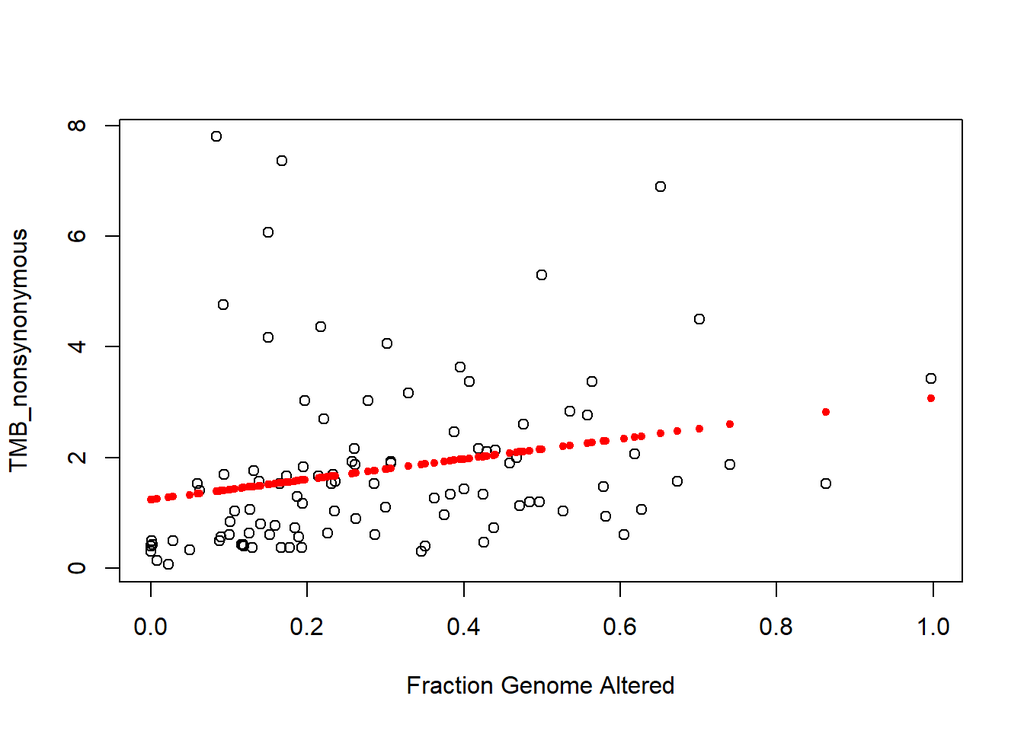

```r
#Predicted vs observed values
plot(q.four$I, q.four$O, xlab="Fraction Genome Altered", ylab="TMB_nonsynonymous")
points(q.four$I, predict(q.four.lm), col="red", pch=20)
```

# 6 Question 5

**Identify the genes most positively correlated with ERBB2 in normal and cancer samples. Write code to calculate the pearson correlation between ERBB2 and all genes in the mRNA expression table for normal and tumor samples separately. Save all correlation coefficients and p-values for each gene and perform multiple hypothesis testing correction for the p-values. Report the top 10 correlated genes in both the normal and tumor groups, including their correlation coefficients and p-adjust values.**

I made a for loop that performed separate Spearman tests comparing the ERBB2 gene expression with the rest of the genes for normal and tumor tissue samples. I chose the Spearman test because the data is not normally distributed.

```r
pn <- character(0); pt <- character(0) #p-value variables
pvn <- character(0); pvt <- character(0) #p-value vectors
Cn <- character(0); Ct <- character(0) #correlation coeff. variables
Cvn <- character(0); Cvt <- character(0) #correlation coeff. vectors
spear.n <- character(0); spear.t <- character(0) #Spearman correlation test variables
for (i in 1:nrow(mRNA.data)) {
  #Spearman correlation test for normal tissues
    spear.n <- cor.test(ERBB2.n, as.numeric(mRNA.data[i, grep("11", names(mRNA.data), value = TRUE)]), method = "spearman")
    pn <- as.numeric(spear.n$p.value) #P-value
    pvn <- append(pvn, pn) #Append to p-value vector
    Cn <- as.numeric(spear.n$estimate) #correlation coeff.
    Cvn <- append(Cvn, Cn) #Append to correlation coeff. vector
  #Spearman correlation test for tumor tissues
    spear.t <- cor.test(ERBB2.t, as.numeric(mRNA.data[i, grep("01", names(mRNA.data), value = TRUE)]), method = "spearman")
    pt <- as.numeric(spear.t$p.value) #P-value
    pvt <- append(pvt, pt) #Append to p-value vector
    Ct <- as.numeric(spear.t$estimate) #correlation coeff.
    Cvt <- append(Cvt, Ct) #Append to correlation coeff. vector
}
```

```r
#Adjusted normal tissue p-values
pvn.adj <- p.adjust(pvn, method = "bonferroni")
#Adjusted tumor tissue p-values
pvt.adj <- p.adjust(pvt, method = "bonferroni")
count <- 10 #Counter for below while loop
i <- 0 #Counter for gene index
#Temp vectors
temp.pn <- pvn.adj
temp.Cn <- Cvn
temp.pt <- pvt.adj
temp.Ct <- Cvt
#Vectors for top 10 genes and their corresponding correlation coeffs. and p-values
genes.n <- character(0) #Genes for normal tissue
genes.t <- character(0) #Genes for tumor tissue
p.values.n <- character(0) #P-values for normal tissue
p.values.t <- character(0) #P-values for tumor tissue
corr.n <- character(0) #Correlation coeffs for normal tissue
corr.t <- character(0) #Correlation coeffs for tumor tissue
#Top 10 genes with correlation coefficients and p-values:
while (count > 0) { #While count is greater than 0:
  if (count == 0) { #If count equals 0, break loop
    break
  }else {
    #Append genes with max correlation coefficients
    genes.n <- append(genes.n, mRNA.data[which.max(temp.Cn) + i, 1])
    genes.t <- append(genes.t, mRNA.data[which.max(temp.Ct) + i, 1])
    #Append p-values with max correlation coefficients
    p.values.n <- append(p.values.n, temp.pn[which.max(temp.Cn)])
    p.values.t <- append(p.values.t, temp.pt[which.max(temp.Ct)])
    #Append max correlation coefficients
    corr.n <- append(corr.n, temp.Cn[which.max(temp.Cn)])
    corr.t <- append(corr.t, temp.Ct[which.max(temp.Ct)])
    #Remove max p-values and coefficents
    temp.pn <- temp.pn[-which.max(temp.Cn)]
    temp.Cn <- temp.Cn[-which.max(temp.Cn)]
    temp.pt <- temp.pt[-which.max(temp.Ct)]
    temp.Ct <- temp.Ct[-which.max(temp.Ct)]
    i <- i + 1 #To be added to next top gene index
    count <- count - 1 #While loop counter decreases
  }
}
#Top 10 positively correlated genes to ERBB2 mRNA expression in normal tissue in order of descending correlation:
for (i in 1:10) {
  print(paste(genes.n[i], "has a correlation coefficient of", signif(as.numeric(corr.n[i], 7)), "and a p-value of", signif(as.numeric(p.values.n[i], 7))))
}
```

```
## [1] "ERBB2 has a correlation coefficient of 1 and a p-value of 0"
## [1] "ZBTB42 has a correlation coefficient of 0.939405 and a p-value of 1.83741e-44"
## [1] "CRCP has a correlation coefficient of 0.915992 and a p-value of 1.49139e-37"
## [1] "DDRGK1 has a correlation coefficient of 0.914892 and a p-value of 2.79794e-37"
## [1] "SEZ6L has a correlation coefficient of 0.914257 and a p-value of 4.00753e-37"
## [1] "KIAA1529 has a correlation coefficient of 0.913129 and a p-value of 7.53466e-37"
## [1] "DLGAP2 has a correlation coefficient of 0.912868 and a p-value of 8.70976e-37"
## [1] "C17orf48 has a correlation coefficient of 0.912091 and a p-value of 1.33696e-36"
## [1] "C9orf91 has a correlation coefficient of 0.911778 and a p-value of 1.5876e-36"
## [1] "LMAN1L has a correlation coefficient of 0.910345 and a p-value of 3.45371e-36"
```

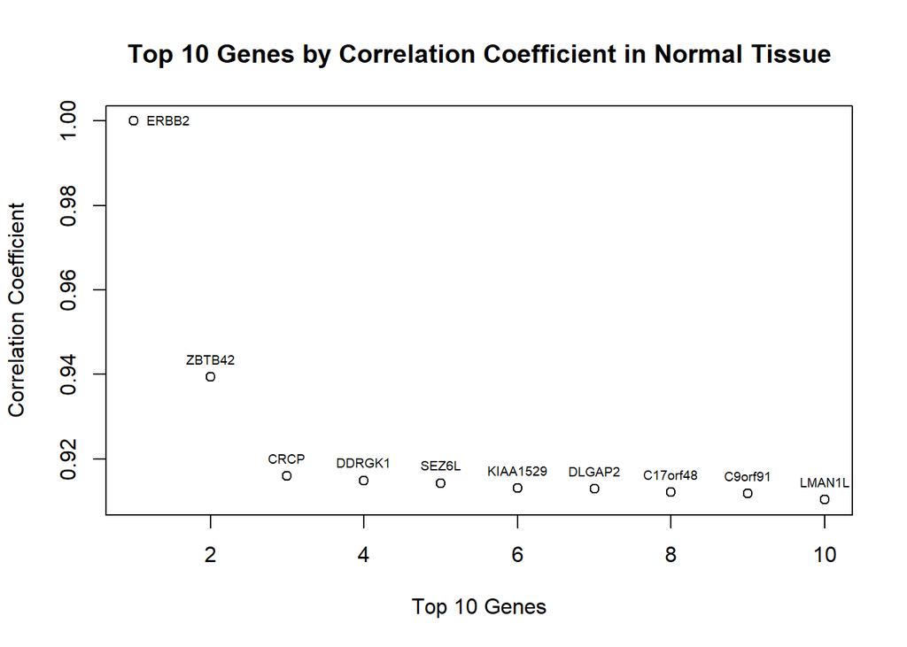

```r
#Plot of Coefficients
plot(corr.n, xlab="Top 10 Genes", ylab="Correlation Coefficient", main="Top 10 Genes by Correlation Coefficient in Normal Tissue")
pos_vector <- rep(3, length(genes.n))
pos_vector[genes.n %in% genes.n[1]] <- 4 #Every gene label except the first one is as position 3
text(corr.n, labels=genes.n, cex = 0.6, pos = pos_vector)
```

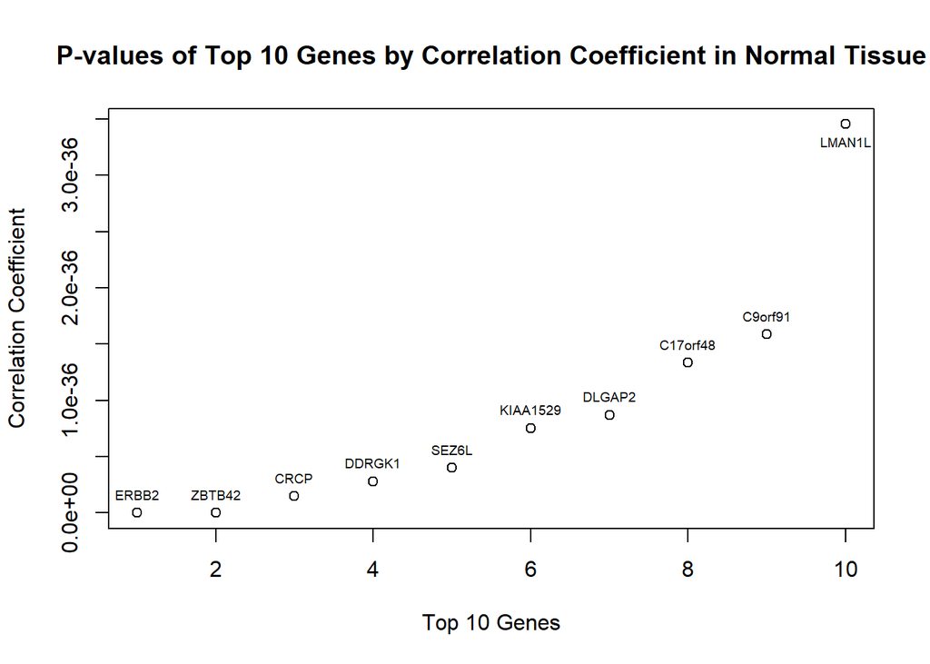

```r
#Plot of p-values
plot(p.values.n, xlab="Top 10 Genes", ylab="Correlation Coefficient", main="P-values of Top 10 Genes by Correlation Coefficient in Normal Tissue")
pos_vector <- rep(3, length(genes.n))
pos_vector[genes.n %in% genes.n[10]] <- 1 #Every gene label except the 10th one is at position 3
text(p.values.n, labels=genes.n, cex = 0.6, pos = pos_vector)
```

```r
#Top 10 positively correlated genes to ERBB2 mRNA expression in tumor tissue in order of descending correlation:
for (i in 1:10) {
  print(paste(genes.t[i], "has a correlation coefficient of",
signif(as.numeric(corr.t[i], 7)), "and a p-value of", signif(as.numeric(p.values.t[i], 7))))
}
```

```
## [1] "ERBB2 has a correlation coefficient of 1 and a p-value of 0"
## [1] "PGAP3 has a correlation coefficient of 0.825462 and a p-value of 0"
## [1] "STARD3 has a correlation coefficient of 0.745983 and a p-value of 3.09813e-15"
## [1] "OSBP2 has a correlation coefficient of 0.667838 and a p-value of 0"
## [1] "C17orf46 has a correlation coefficient of 0.655342 and a p-value of 1.17111e-09"
## [1] "FBXL2 has a correlation coefficient of 0.627531 and a p-value of 2.61159e-08"
## [1] "MED27 has a correlation coefficient of 0.619294 and a p-value of 0"
## [1] "GREM2 has a correlation coefficient of 0.605674 and a p-value of 2.43056e-07"
## [1] "SUOX has a correlation coefficient of 0.580662 and a p-value of 2.55591e-06"
## [1] "PIP5K1A has a correlation coefficient of 0.579416 and a p-value of 0"
```

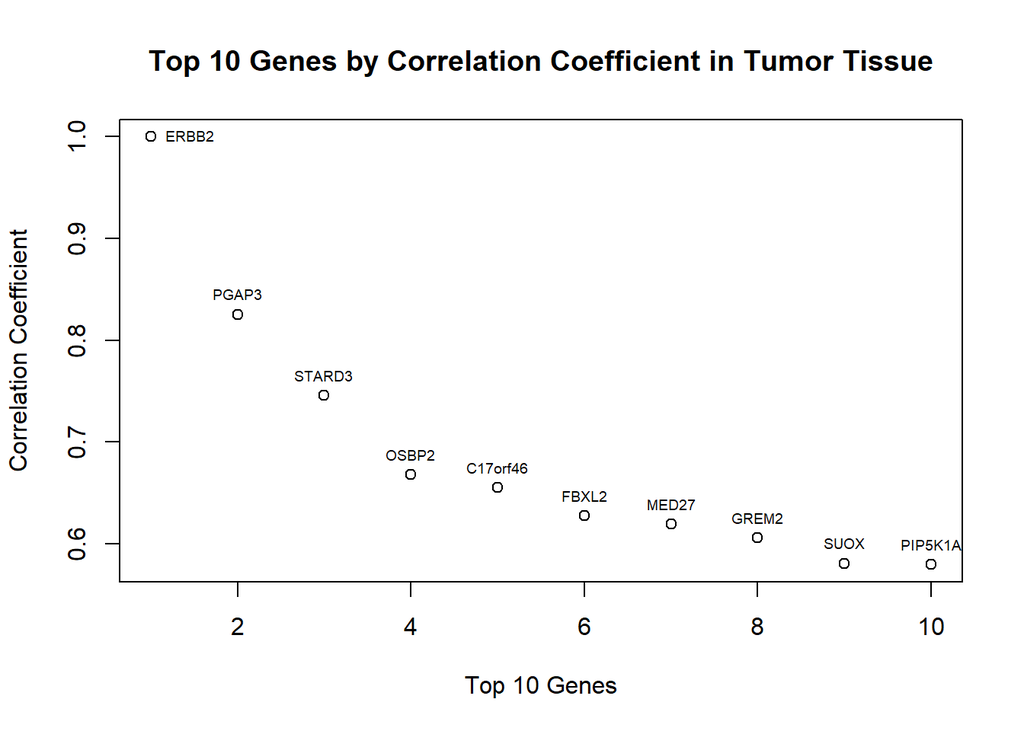

```r
#Plot of coefficients
plot(corr.t, xlab="Top 10 Genes", ylab="Correlation Coefficient", main="Top 10 Genes by Correlation Coefficient in Tumor Tissue")
pos_vector <- rep(3, length(genes.t))
pos_vector[genes.t %in% genes.t[1]] <- 4 #Every gene label except the first one is at position 3
text(corr.t, labels=genes.t, cex = 0.6, pos = pos_vector)
```

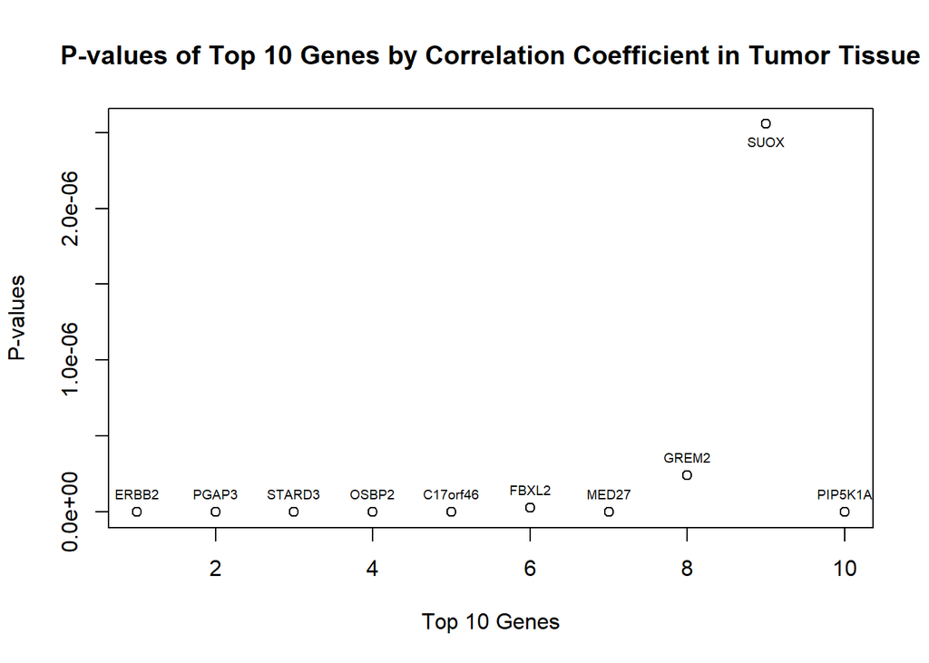

```r
#Plot of p-values
plot(p.values.t, xlab="Top 10 Genes", ylab="P-values", main="P-values of Top 10 Genes by Correlation Coefficient in Tumor Tissue")
pos_vector <- rep(3, length(genes.t))
pos_vector[genes.t %in% genes.t[9]] <- 1 #Every gene label except the 9th one is at position 3
text(p.values.t, labels=genes.t, cex = 0.6, pos = pos_vector)
```